# Plot review: plot.net_outcome()

2026-09-28

## What is being compared with what

`hon_outcome()` gives every **actor** (here: a student) one number per feature. The number is an average: take every higher-order state the student passed through (for example “`debug -> code`”, the state *code* reached from *debug*), look up that state’s centrality in the pooled network, and average over the student’s visits. A student whose trajectory keeps returning to central states gets a high value; one who spends time in peripheral states gets a low one.

The regression then compares **students with each other**: do students with a higher average exposure to central states have a different outcome? Nothing is compared within a student, and no single node or motif is being tested.

Each section shows two views of the same fit:

1. **Per-SD effects** (`plot(fit)`, the default): how much the outcome differs between two students one standard deviation apart on that feature, with the other features held fixed. All features sit on the same axis, so they can be compared directly.
2. **Contrasts** (`plot(fit, what = "contrasts")`): two hypothetical students per feature, one at the 25th and one at the 75th percentile of that feature, every other feature at its average; the plot shows the predicted outcome for each.

```r
simulate_students <- function(n_classes = 20L, per_class = 6L) {
  class_id <- rep(sprintf("class%02d", seq_len(n_classes)), each = per_class)
  n <- length(class_id)
  class_tilt <- rep(stats::rnorm(n_classes, sd = 0.8), each = per_class)
  class_effect <- rep(stats::rnorm(n_classes, sd = 3), each = per_class)
  debug_share <- stats::plogis(-0.5 + class_tilt + stats::rnorm(n, sd = 0.8))
  data.frame(
    student = sprintf("s%03d", seq_len(n)), class = class_id,
    debug_share = debug_share,
    score = 70 - 12 * debug_share + class_effect + stats::rnorm(n, sd = 3),
    completed = stats::rbinom(n, 1L, stats::plogis(2 - 4 * debug_share)),
    stringsAsFactors = FALSE)
}
simulate_logs <- function(students, n_motifs = 12L) {
  motifs <- list(plan = c("plan", "code", "test"),
                 debug = c("debug", "code", "debug"),
                 read = c("read", "plan", "code"),
                 review = c("test", "read", "plan"))
  rows <- lapply(seq_len(nrow(students)), \(i) {
    p <- students$debug_share[i]
    pick <- sample(names(motifs), n_motifs, replace = TRUE,
                   prob = c((1 - p) / 3, p, (1 - p) / 3, (1 - p) / 3))
    actions <- unlist(motifs[pick], use.names = FALSE)
    data.frame(student = students$student[i], step = seq_along(actions),
               action = actions, stringsAsFactors = FALSE)
  })
  do.call(rbind, rows)
}
set.seed(2026)
students <- simulate_students()
logs <- simulate_logs(students)
hon <- build_hon(logs, action = "action", actor = "student", time = "step",
                 max_order = 2L)
```

## 1. Gaussian score, two centralities, CR3 over 20 classes

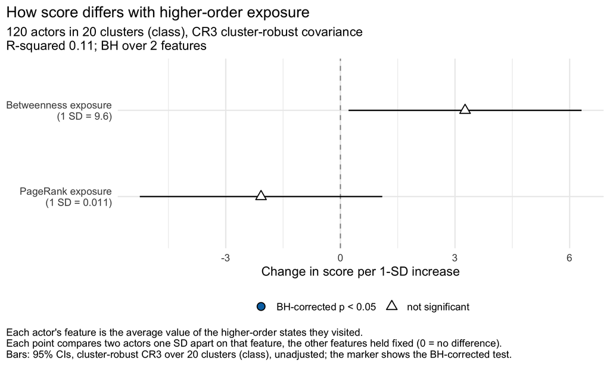

```r
fit_two <- hon_outcome(hon, outcome = students, sequences = logs,
                       by = "student", outcome_col = "score",
                       action = "action", time = "step",
                       centrality_type = c("pagerank", "betweenness"),
                       nested_in = "class")
plot(fit_two)
```

**Reading it.** Students one SD higher in Betweenness exposure (1 SD = 9.6) score 3.26 points higher (95% CI 0.21 to 6.31; BH-adjusted p = 0.075). Students one SD higher in PageRank exposure (1 SD = 0.011) score 2.08 points lower (95% CI -5.25 to 1.10; BH-adjusted p = 0.19). The two features are adjusted for each other, and the intervals are cluster-robust because students in the same class are not independent.

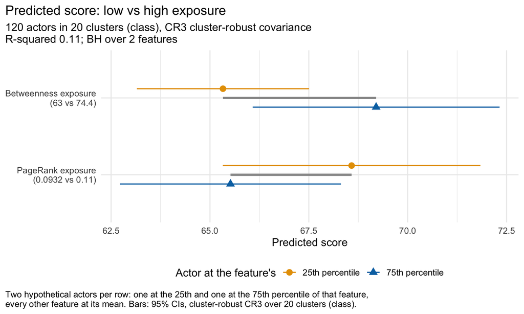

```r
plot(fit_two, what = "contrasts")
```

For PageRank exposure, a student at the 25th percentile (0.0932) is predicted at 68.58 (95% CI 65.32 to 71.84) and one at the 75th percentile (0.11) at 65.52 (62.73 to 68.31): a difference of -3.06 (95% CI -7.74 to 1.62). For Betweenness exposure, a student at the 25th percentile (63) is predicted at 65.33 (95% CI 63.15 to 67.51) and one at the 75th percentile (74.4) at 69.20 (66.08 to 72.32): a difference of 3.87 (95% CI 0.25 to 7.49). The grey bar is the gap between the two hypothetical students; when the two intervals overlap heavily the gap is not distinguishable from zero.

```r
as.data.frame(fit_two)
```

```
      feature  estimate std_error  conf_low conf_high statistic          p
1    pagerank -2.076985  1.515959 -5.249923  1.095954 -1.370079 0.18663565
2 betweenness  3.262810  1.456918  0.213446  6.312174  2.239529 0.03727783
       p_adj   n feature_sd effect_per_sd per_sd_low per_sd_high         scale
1 0.18663565 120 0.01138363     -2.076985  -5.249923    1.095954 outcome units
2 0.07455566 120 9.56172743      3.262810   0.213446    6.312174 outcome units
```

```r
as.data.frame(fit_two, what = "contrasts")
```

```
      feature   low_value high_value predicted_low predicted_low_ci_low
1    pagerank  0.09319958  0.1099807      68.58094             65.32461
2 betweenness 63.01388889 74.3611111      65.32900             63.15256
  predicted_low_ci_high predicted_high predicted_high_ci_low
1              71.83728       65.51916              62.72789
2              67.50543       69.20108              66.07988
  predicted_high_ci_high difference std_error   conf_low conf_high ratio
1               68.31042  -3.061785  2.234750 -7.7391699  1.615600    NA
2               72.32228   3.872086  1.728973  0.2533036  7.490868    NA
  ratio_low ratio_high         scale
1        NA         NA outcome units
2        NA         NA outcome units
```

## 2. Same fit, model-based covariance (no nesting)

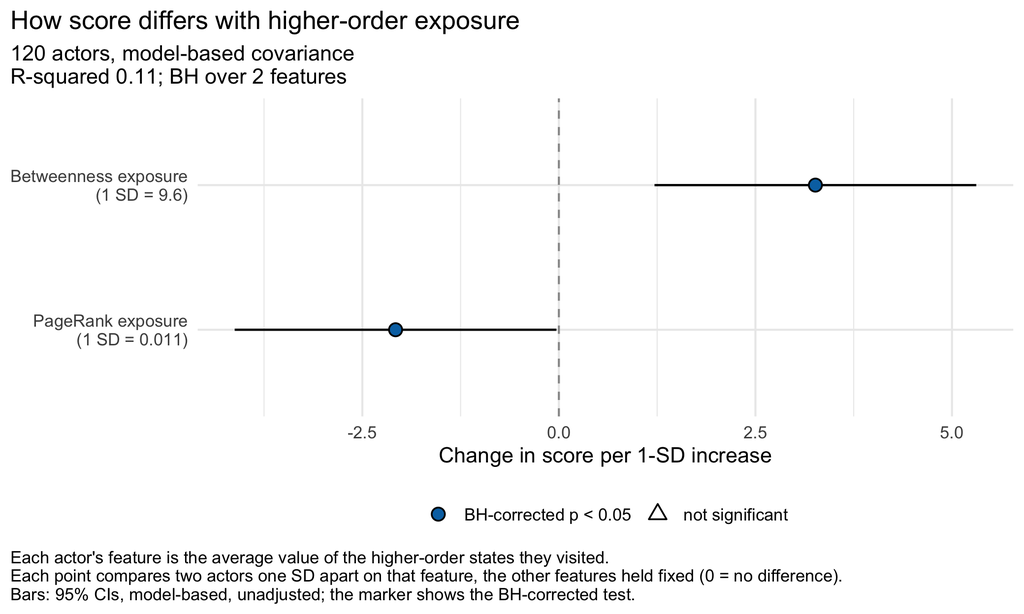

```r
fit_naive <- hon_outcome(hon, outcome = students, sequences = logs,
                         by = "student", outcome_col = "score",
                         action = "action", time = "step",
                         centrality_type = c("pagerank", "betweenness"))
plot(fit_naive)
```

**Reading it.** Students one SD higher in Betweenness exposure (1 SD = 9.6) score 3.26 points higher (95% CI 1.22 to 5.31; BH-adjusted p = 0.004). Students one SD higher in PageRank exposure (1 SD = 0.011) score 2.08 points lower (95% CI -4.12 to -0.03; BH-adjusted p = 0.047). The point estimates are the same as in section 1; only the intervals change. These treat the 120 students as independent, which the class structure makes false, so they are too narrow.

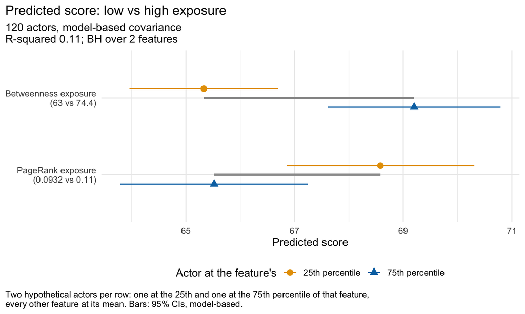

```r
plot(fit_naive, what = "contrasts")
```

For PageRank exposure, a student at the 25th percentile (0.0932) is predicted at 68.58 (95% CI 66.85 to 70.31) and one at the 75th percentile (0.11) at 65.52 (63.79 to 67.25): a difference of -3.06 (95% CI -6.08 to -0.05). For Betweenness exposure, a student at the 25th percentile (63) is predicted at 65.33 (95% CI 63.96 to 66.70) and one at the 75th percentile (74.4) at 69.20 (67.61 to 70.79): a difference of 3.87 (95% CI 1.44 to 6.30).

## 3. Gaussian, all five features (near-collinear)

```r
fit_all <- hon_outcome(hon, outcome = students, sequences = logs,
                       by = "student", outcome_col = "score",
                       action = "action", time = "step",
                       features = c("centrality", "honem"),
                       nested_in = "class")
```

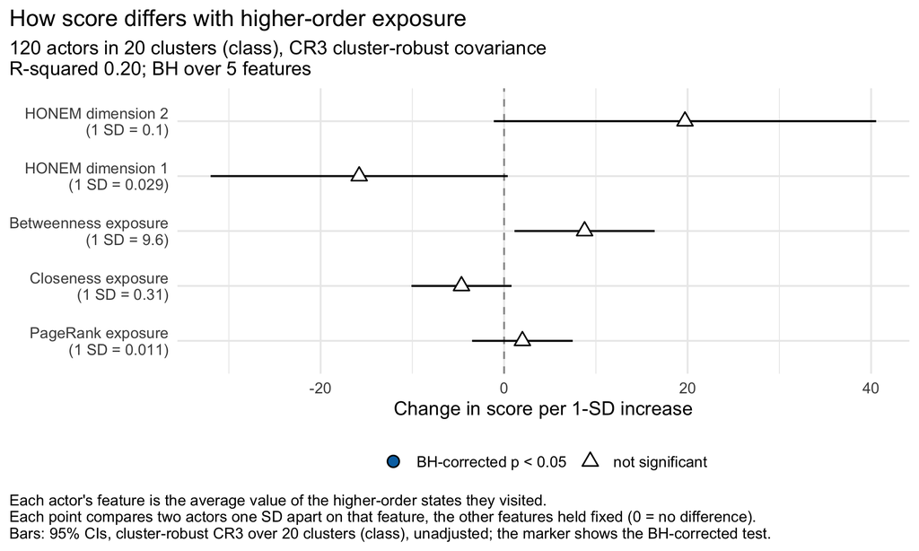

```r
plot(fit_all, what = "per_sd")
```

**Reading it.** Five related features compete for the same signal, so each per-SD effect is “holding the other four fixed” – a comparison between students who differ on one feature but not on the others, which barely exist in these data. The wide intervals are that collinearity (scaled condition index 71.91), not an absence of signal.

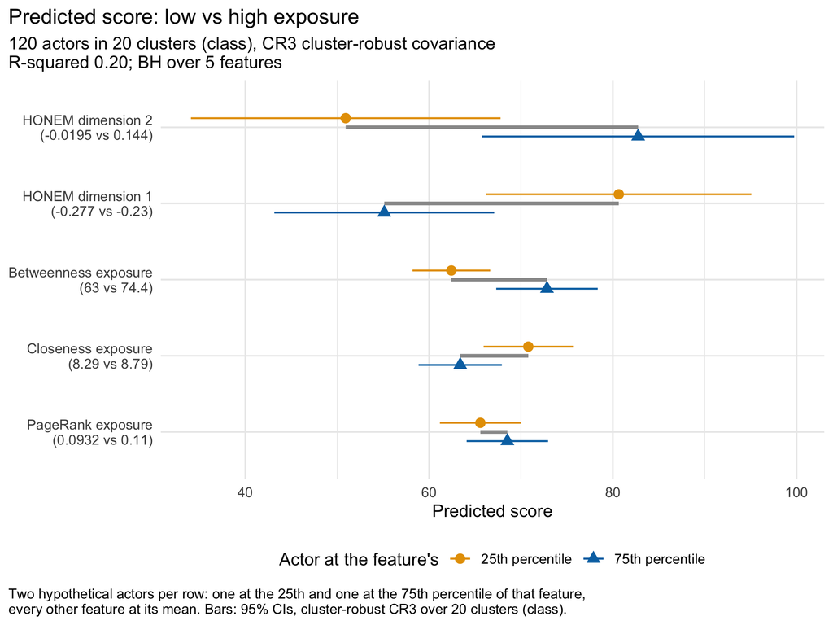

```r
plot(fit_all, what = "contrasts")
```

For PageRank exposure, a student at the 25th percentile (0.0932) is predicted at 65.58 (95% CI 61.18 to 69.99) and one at the 75th percentile (0.11) at 68.52 (64.09 to 72.95): a difference of 2.94 (95% CI -5.14 to 11.02). For Betweenness exposure, a student at the 25th percentile (63) is predicted at 62.42 (95% CI 58.20 to 66.65) and one at the 75th percentile (74.4) at 72.83 (67.31 to 78.36): a difference of 10.41 (95% CI 1.34 to 19.47). For Closeness exposure, a student at the 25th percentile (8.29) is predicted at 70.80 (95% CI 65.93 to 75.66) and one at the 75th percentile (8.79) at 63.39 (58.86 to 67.92): a difference of -7.41 (95% CI -16.10 to 1.28). For HONEM dimension 1, a student at the 25th percentile (-0.277) is predicted at 80.65 (95% CI 66.21 to 95.08) and one at the 75th percentile (-0.23) at 55.12 (43.15 to 67.09): a difference of -25.52 (95% CI -51.69 to 0.64). For HONEM dimension 2, a student at the 25th percentile (-0.0195) is predicted at 50.92 (95% CI 34.07 to 67.77) and one at the 75th percentile (0.144) at 82.76 (65.77 to 99.74): a difference of 31.83 (95% CI -1.82 to 65.48).

## 4. Binomial completion, CR3 over 20 classes

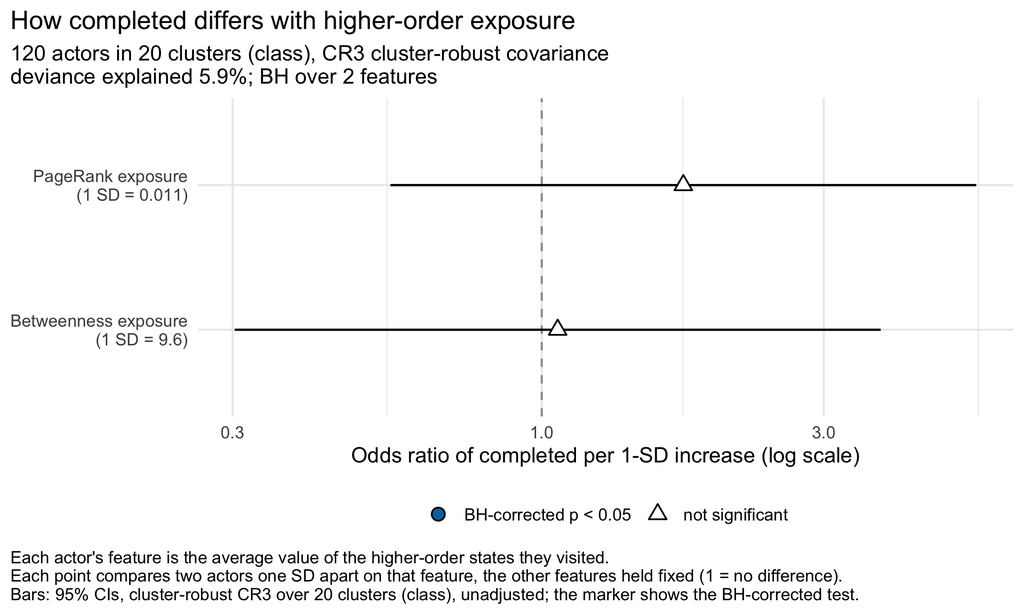

```r
fit_completed <- hon_outcome(hon, outcome = students, sequences = logs,
                             by = "student", outcome_col = "completed",
                             action = "action", time = "step",
                             centrality_type = c("pagerank", "betweenness"),
                             nested_in = "class", family = "binomial")
plot(fit_completed)
```

**Reading it.** For a 0/1 outcome the effect is an odds ratio on a log axis; 1 means no association. Students one SD higher in PageRank exposure (1 SD = 0.011) have 1.74 times the odds of completing (95% CI 0.55 to 5.44; BH-adjusted p = 0.65). Students one SD higher in Betweenness exposure (1 SD = 9.6) have 1.06 times the odds of completing (95% CI 0.30 to 3.74; BH-adjusted p = 0.92).

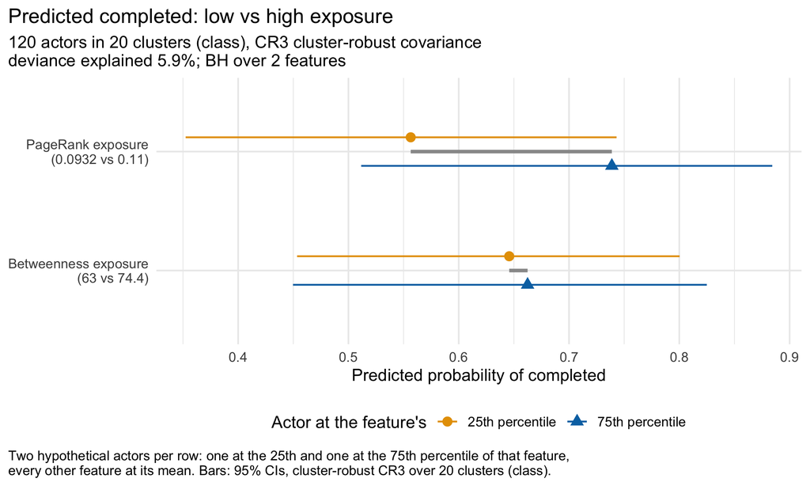

```r
plot(fit_completed, what = "contrasts")
```

The contrast turns the odds ratio back into probabilities of completing. For PageRank exposure, a student at the 25th percentile (0.0932) is predicted at 55.65% (95% CI 35.24% to 74.31%) and one at the 75th percentile (0.11) at 73.88% (51.16% to 88.43%): a difference of 18.24 percentage points (95% CI -18.35 to 54.82). For Betweenness exposure, a student at the 25th percentile (63) is predicted at 64.58% (95% CI 45.34% to 80.03%) and one at the 75th percentile (74.4) at 66.24% (44.97% to 82.49%): a difference of 1.66 percentage points (95% CI -32.08 to 35.41).

## 5. Poisson on real sessions, CR3 over 34 projects

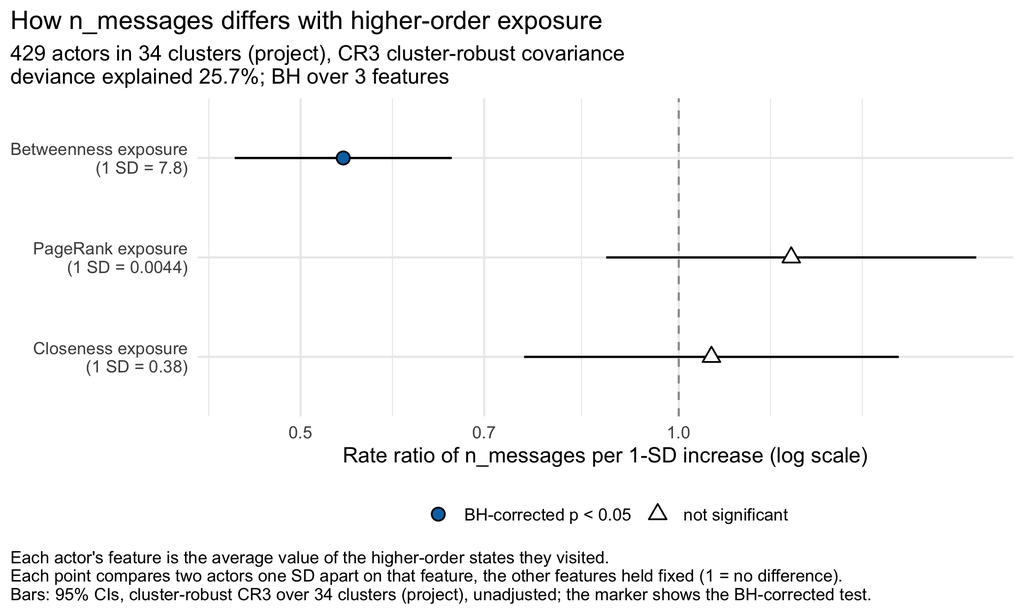

```r
session_messages <- aggregate(cbind(n_messages = message_id) ~
                                session_id + project,
                              data = human_long,
                              FUN = \(m) length(unique(m)))
session_hon <- build_hon(human_long, action = "code", actor = "session_id",
                         time = "order_in_session", max_order = 2L,
                         min_freq = 50L)
session_fit <- hon_outcome(session_hon, outcome = session_messages,
                           sequences = human_long, by = "session_id",
                           outcome_col = "n_messages", action = "code",
                           time = "order_in_session",
                           centrality_type = c("pagerank", "betweenness",
                                               "closeness"),
                           nested_in = "project", family = "poisson")
plot(session_fit)
```

**Reading it.** Here the actors are sessions and the outcome is the number of human messages, so the effect is a rate ratio (log axis, 1 = no association). Sessions one SD higher in Betweenness exposure (1 SD = 7.8) have 0.54 times the expected count (95% CI 0.44 to 0.66; BH-adjusted p = 1.2e-06). Sessions one SD higher in PageRank exposure (1 SD = 0.0044) have 1.23 times the expected count (95% CI 0.88 to 1.73; BH-adjusted p = 0.34). Sessions one SD higher in Closeness exposure (1 SD = 0.38) have 1.06 times the expected count (95% CI 0.75 to 1.50; BH-adjusted p = 0.72). This is a mechanics demonstration: outcome and features come from the same sessions.

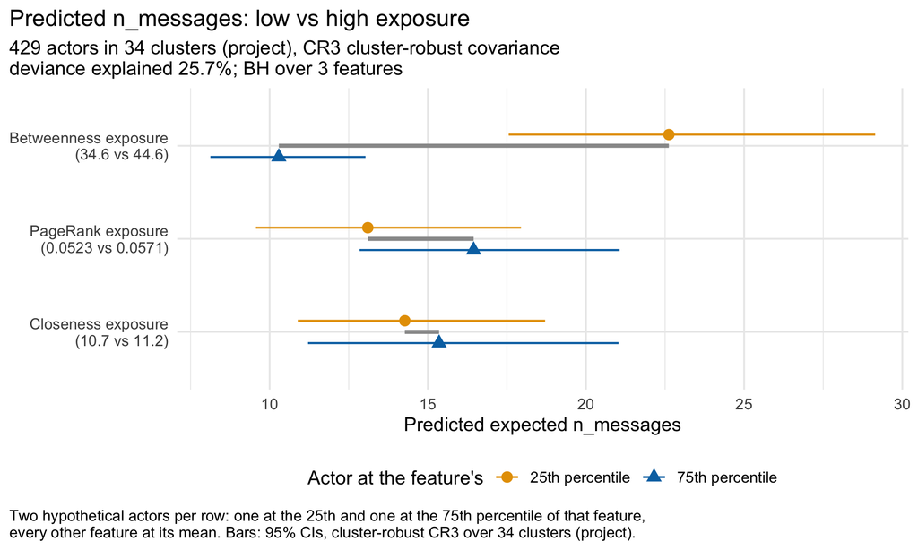

```r
plot(session_fit, what = "contrasts")
```

For PageRank exposure, a session at the 25th percentile (0.0523) is predicted at 13.10 (95% CI 9.57 to 17.95) and one at the 75th percentile (0.0571) at 16.45 (12.84 to 21.06): a difference of 3.35 (95% CI -2.06 to 8.75). For Betweenness exposure, a session at the 25th percentile (34.6) is predicted at 22.62 (95% CI 17.56 to 29.14) and one at the 75th percentile (44.6) at 10.29 (8.13 to 13.03): a difference of -12.33 (95% CI -17.42 to -7.23). For Closeness exposure, a session at the 25th percentile (10.7) is predicted at 14.27 (95% CI 10.89 to 18.71) and one at the 75th percentile (11.2) at 15.36 (11.21 to 21.03): a difference of 1.08 (95% CI -5.16 to 7.33).

## 6. The old view, kept as `what = "raw"`

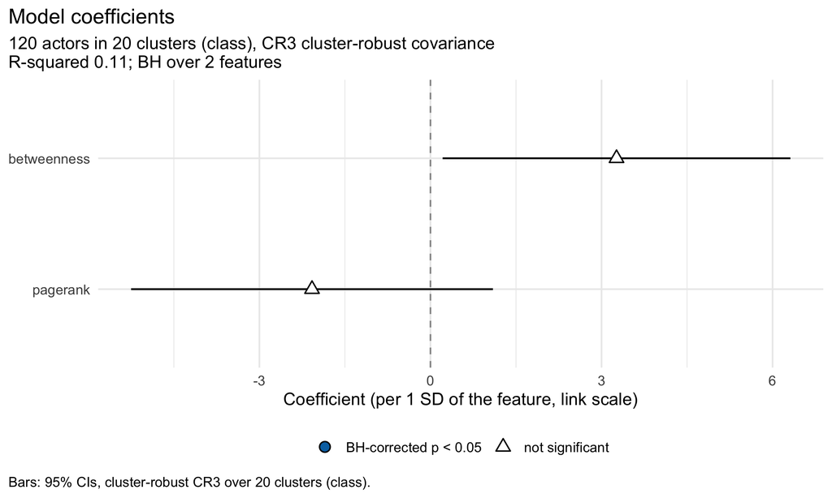

```r
plot(fit_two, what = "raw")
```